# Dealing with label switching: relabelling in Bayesian mixture models by pivotal units

Leonardo Egidi

2024-05-29

In this vignette we explore the fit of Gaussian mixture models and the relabelling pivotal method proposed in Egidi et al. (2018b) through the `pivmet` package. First of all, we load the package:

```r
library(pivmet)
library(bayesmix)
library(bayesplot)
```

The `pivmet` package provides a simple framework to (i) fit univariate and multivariate mixture models according to a Bayesian flavour and detect the pivotal units, via the `piv_MCMC` function; (ii) perform the relabelling step via the `piv_rel` function.

There are two main functions used for this task.

The function `piv_MCMC`:

- **performs MCMC sampling** for Gaussian mixture models using the underlying `rjags` or `rstan` packages (chosen by the users through the optional function argument `software`, by default set to `rjags`). Precisely the package uses: the `JAGSrun` function of the `bayesmix` package for univariate mixture models; the `run.jags` function of the `runjags` package for bivariate mixture models; the `stan` function of the `rstan` package for both univariate and bivariate mixture models.
- **Post-processes the chains** and randomly switches their values (Frühwirth-Schnatter 2001).
- **Builds a co-association matrix for the $N$ units**. After $H$ MCMC iterations, the function implements a clustering procedure with $k$ groups, the user may choose among agglomerative or divisive hierarchical clustering through the optional argument `clustering`. Using the latent formulation for mixture models, we denote with $[z_i]_h$ the group allocation of the $i$-th unit at the $h$-th iteration. In such a way, a co-association matrix $C$ for the $N$ statistical units is built, where the single cell $c_{ip}$ is the fraction of times the unit $i$ and the unit $p$ belong to the same group along the $H$ MCMC iterations:

$$c_{ip} = \frac{n_{ip}}{H}=\frac{1}{H}
\sum_{h=1}^{H}|[z_i]_h=[z_p]_h|,$$
where $|\cdot|$ denotes the event indicator and $n_{ip}$ is the number of times the units $i, \ p$ belong to the same group along the sampling.

- **Extracts the pivots**, one for each group, which are (pairwise) separated units with (posterior) probability one (that is, the posterior probability of any two of them being in the same group is approximately zero). We denote them by $i_1,\ldots,i_k$. The user may choose among four procedures for extracting the pivotal units with the optional argument `piv.criterion`. For group $j$ containing $J_j$ units, one can choose:
- $i^{*}$ that maximizes $\sum_{p \in J_j}c_{ip}$ (`"maxsumint"`, default method);
- $i^{*}$ that maximizes $\sum_{p \in J_j}c_{ip}- \sum_{p \not\in J_j}c_{ip}$ (`"maxsumdiff"`);
- $i^{*}$ that minimizes $\sum_{p \not\in J_j}c_{ip}$ (`"minsumnoint"`).

These three methods are applied by the internal function `piv_sel`. Alternatively, when $k <5$, the user can set `piv.criterion="MUS"` (Egidi et al. 2018a) which performs a sequential search of identity submatrices within the matrix $C$ via the internal function `MUS`.

The function `piv_rel`:

- **performs the relabelling algorithm** using the $k$ pivotal units as groups identifiers. The pivotal units previously detected play a central role, yielding to the following relabelling for the $h$-th iteration:

$$\begin{align*}
[\mu_{j}]_h=&[\mu_{z_{i_{j}}}]_h \\
[z_{i}]_h =j & \mbox{ for } i : [z_i]_h=[z_{i_{j}}]_h,\\
\end{align*}$$
where $\boldsymbol{\mu}=(\mu_1,\mu_2,\ldots,\mu_k)$ is the vector of the means parameters and $\boldsymbol{z}=(z_1,z_2,\ldots,z_N)$ an i.i.d. vector of latent variables taking values in $\{1,2,\ldots,k \}$ and denoting the group membership of each statistical unit.

`piv_rel` takes as input the MCMC output from `piv_MCMC` and returns the relabelled chains and the corresponding posterior estimates.

## Example: bivariate Gaussian data

Suppose now that $\boldsymbol{y}_i \in \mathbb{R}^2$ and assume that:

$$\boldsymbol{y}_i \sim
\sum_{j=1}^{k}\eta_{j}\mathcal{N}_{2}(\boldsymbol{\mu}_{j},
\boldsymbol{\Sigma})$$
where $\boldsymbol{\mu}_j$ is the mean vector for group $j$, $\boldsymbol{\Sigma}$ is a positive-definite covariance matrix and the mixture weight $\eta_j= P(z_i=j)$ as for the one-dimensional case. We may generate Gaussian mixture data through the function `piv_sim`, specifying the sample size $N$, the desired number of groups $k$ and the $k \times 2$ matrix for the $k$ mean vectors. The argument `W` handles the weights for a nested mixture, in which the $j$-th component is in turn modelled as a two-component mixture, with covariance matrices $\boldsymbol{\Sigma}_{p1}, \boldsymbol{\Sigma}_{p2}$, respectively.

```r
set.seed(500)
N  <- 200
k  <- 3
D <- 2
nMC <- 2000
M1 <- c(-10,8)
M2 <- c(10,.1)
M3 <- c(30,8)
# matrix of input means
Mu <- rbind(M1,M2,M3)
# covariance matrices for the two subgroups
Sigma.p1 <- diag(D)
Sigma.p2 <- (10^2)*diag(D)
# subgroups' weights
W   <- c(0.2,0.8)
# simulate data
sim <- piv_sim(N = N, k = k, Mu = Mu,
 Sigma.p1 = Sigma.p1, Sigma.p2 = Sigma.p2, W = W)
```

The function `piv_MCMC` requires only three mandatory arguments: the data object `y`, the number of components `k` and the number of MCMC iterations, `nMC`. By default, it performs Gibbs sampling using the `runjags` package. If `software="rjags"`, for bivariate data the priors are specified as:

$$\begin{align}
\boldsymbol{\mu}_j \sim & \mathcal{N}_2(\boldsymbol{\mu}_0, S_2)\\
\Sigma^{-1} \sim & \mbox{Wishart}(S_3, 3)\\
\eta \sim & \mbox{Dirichlet}(\boldsymbol{\alpha}),
\end{align}$$

where $\boldsymbol{\alpha}$ is a $k$-dimensional vector and $S_2$ and $S_3$ are positive definite matrices. By default, $\boldsymbol{\mu}_0=\boldsymbol{0}$, $\boldsymbol{\alpha}=(1,\ldots,1)$ and $S_2$ and $S_3$ are diagonal matrices, with diagonal elements equal to 1e+05. Different values can be specified for the hyperparameters $\boldsymbol{\mu}_0, S_2, S_3$ and $\boldsymbol{\alpha}$: `priors =list(mu_0 = c(1,1), S2 = ..., S3 = ..., alpha = ...)}`, with the constraint for $S2$ and $S3$ to be positive definite, and $\boldsymbol{\alpha}$ a vector of dimension $k$ with nonnegative elements.

If `software="rstan"`, the function performs Hamiltonian Monte Carlo (HMC) sampling. In this case the priors are specified as:

$$\begin{align}
\boldsymbol{\mu}_j \sim & \mathcal{N}_2(\boldsymbol{\mu}_0,
LD^*L^{T})\\
L \sim & \mbox{LKJ}(\eta)\\
D_{1,2} \sim & \mbox{HalfCauchy}(0, \sigma_d).
\end{align}$$

The covariance matrix is expressed in terms of the LDL decomposition as $LD^*L^{T}$, a variant of the classical Cholesky decomposition, where $L$ is a $2 \times 2$ lower unit triangular matrix and $D^*$ is a $2 \times 2$ diagonal matrix. The Cholesky correlation factor $L$ is assigned a LKJ prior with $\epsilon$ degrees of freedom, which, combined with priors on the standard deviations of each component, induces a prior on the covariance matrix; as $\epsilon \rightarrow \infty$ the magnitude of correlations between components decreases, whereas $\epsilon=1$ leads to a uniform prior distribution for $L$. By default, the hyperparameters are $\boldsymbol{\mu}_0=\boldsymbol{0}$, $\sigma_d=2.5, \epsilon=1$. Different values can be chosen with the argument: `priors=list(mu_0=c(1,2), sigma_d = 4, epsilon = 2)`.

We fit the model using `rjags` with 2000 MCMC iterations and default priors:

```r
res <- piv_MCMC(y = sim$y, k= k, nMC =nMC,
                piv.criterion = "maxsumdiff")
```

```
#> Compiling rjags model...
#> Calling the simulation using the rjags method...
#> Note: the model did not require adaptation
#> Burning in the model for 1000 iterations...
#> Running the model for 2000 iterations...
#> Simulation complete
#> Note: Summary statistics were not produced as there are >50 monitored
#> variables
#> [To override this behaviour see ?add.summary and ?runjags.options]
#> FALSEFinished running the simulation
#> Calculating summary statistics...
#> Calculating the Gelman-Rubin statistic for 13 variables....
#> Note: Unable to calculate the multivariate psrf
#>
#> JAGS model summary statistics from 8000 samples (chains = 4; adapt+burnin = 2000):
#>
#>             Lower95     Median   Upper95       Mean        SD Mode       MCerr
#> mu[1,1]     -34.643    -11.289    26.045    -9.0266    74.422   --      1.4991
#> mu[2,1]     -12.307     8.5567    11.717     5.2281    7.4464   --      0.2834
#> mu[3,1]      26.131     31.156    34.468     30.835    2.0878   --    0.065093
#> mu[1,2]     -38.367     6.5263    24.639     5.1467    79.076   --     0.83279
#> mu[2,2]     -1.9366     1.2071    8.0542     1.8077    2.5843   --    0.057529
#> mu[3,2]      2.2351     5.6469    8.9093     5.6698    1.7032   --    0.038308
#> tau[1,1]  0.0066207   0.017847  0.023968   0.017196 0.0044008   --  0.00016799
#> tau[2,1] -0.0028016 0.00089274 0.0045477 0.00095305 0.0018915   -- 0.000060697
#> tau[1,2] -0.0028016 0.00089274 0.0045477 0.00095305 0.0018915   -- 0.000060697
#> tau[2,2]  0.0087116   0.011042  0.013969   0.011182 0.0014195   -- 0.000024945
#> eta[1]   1.0905e-06    0.33023   0.43958    0.31449   0.10208   --   0.0032487
#> eta[2]      0.27985    0.41873     0.686    0.42934  0.090432   --   0.0024901
#> eta[3]      0.18087    0.25337    0.3417    0.25617  0.041146   --  0.00095124
#>
#>          MC%ofSD SSeff      AC.10   psrf
#> mu[1,1]        2  2465   0.087141 1.2934
#> mu[2,1]      3.8   690    0.33004 3.2519
#> mu[3,1]      3.1  1029    0.22273 1.2021
#> mu[1,2]      1.1  9016 -0.0010946 1.2918
#> mu[2,2]      2.2  2018    0.20149 2.1184
#> mu[3,2]      2.2  1977   0.082519   1.04
#> tau[1,1]     3.8   686     0.3098 1.2773
#> tau[2,1]     3.2   971    0.19123 1.0762
#> tau[1,2]     3.2   971    0.19123 1.0762
#> tau[2,2]     1.8  3238    0.10486 1.0553
#> eta[1]       3.2   987    0.28663 1.2591
#> eta[2]       2.8  1319    0.26513 1.2054
#> eta[3]       2.3  1871    0.10943 1.0511
#>
#> Total time taken: 14.7 seconds
```

Once we obtain posterior estimates, label switching is likely to occurr. For such a reason, we need to relabel our chains as explained above. In order to relabel the chains, the function `piv_rel` can be used, which only needs the `mcmc = res` argument. Relabelled outputs can be displayed through the function `piv_plot`, with different options for the argument `type`:

- `chains`: plot the relabelled chains;
- `hist`: plot the point estimates against the histogram of the data.

The optional argument `par` takes four possible alternative choices: `mean`, `sd`, `weight` and `all` for the means, standard deviations, weights or all the three mentioned parameters, respectively. By default, `par="all"`.

```r
rel <- piv_rel(mcmc=res)
piv_plot(y = sim$y, mcmc = res, rel_est = rel, par = "mean", type = "chains")
```

[output not shown]

```
#> Description: 3d histogram of the data along with the posterior estimates of the relabelled means (triangle points)
```

[figure not shown]

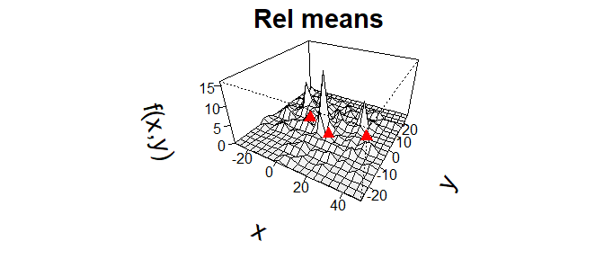

```r
piv_plot(y = sim$y, mcmc = res, rel_est = rel, type = "hist")
```